# metaSABSEB

[figure not shown]

Kanton Zürich

Bildungsdirektion

Bildungsplanung Kanton Zürich

[figure not shown]

# metaSABSEB

Ein R-Package für die Nutzung und Pflege der Metadaten im Qualitätsmonitoring Sek II.

Christina Arn

christina.arn@bi.zh.ch

Bildungsplanung Kanton Zürich

## Ausgangslage

**Bisher**

- PDF-Berichte
- Aufwändige Aktualisierung
- Nicht maschinenlesbar
- Informationen teils schwer auffindbar

**Neu**

- R-Package mit strukturierten Metadaten
- maschinen- und menschenlesbar
- versioniert, nachvollziehbar
- Funktionen für Nutzung und Unterhalt

## Verwendung von metaSABSEB

- **Metadaten abfragen**: R-Package installieren:
  - Entweder: `devtools::install_github("bildungsplanungZH/metaSABSEB", build_vignettes = T)`
  - Oder: `pak::pkg_install("github::bildungsplanungZH/metaSABSEB")`
- **Metadaten bearbeiten**: R-Package klonen und installieren.
- Ausführliche **Dokumentation** gibt es in den Vignetten. Diese können nach der Installation abgerufen werden mit:
  - Metadaten abfragen: `utils::vignette("metadaten_abfragen", "metaSABSEB")`
  - Metadaten bearbeiten: `utils::vignette("metadaten_bearbeiten", "metaSABSEB")`

## Metadaten abfragen

**Alle Metadaten für eine Variable abfragen**

```r
# Alle Metadaten einer Variable abfragen
metaSABSEB::get_meta(var = "Bll_ober")
```

```
$oberthema
[1] "Prozess"

$unterthema
[1] "Soziale Beziehungen"

$umfrage_item
[1] "Wie erleben Sie das Klima in Ihrer Klasse?"

$itemformulierung
[1] "Freundschaften zwischen den Schülerinnen und Schülern sind bei uns nur oberflächlich, letzten Endes arbeitet jeder gegen jeden."

$var_typ
[1] "Skalenitem: Interaktion zwischen Schülerinnen und Schülern"

$umfrage_filter
[1] "school_type_id = 1, 4, 5"

$skalenberechnung
[1] "Mean, Ausschluss wenn Missings >2"

$quelle
[1] "1) Mittelschulerhebung 2004 (Leutwyler & Maag Merki, 2004. Indikatoren zu Kontextmerkmalen gymnasialer Bildung. Perspektive der Schülerinnen und Schüler. Skalen- und Itemdokumentation), Lehrpersonen-Schüler/innen-Beziehung (4 von 6 Items)"

$status
[1] "aktiv"

$values
$values$`1`
[1] "trifft überhaupt nicht zu"

$values$`2`
[1] NA

$values$`3`
[1] NA

$values$`4`
[1] NA

$values$`5`
[1] NA

$values$`6`
[1] "trifft voll und ganz zu"
```

## Metadaten abfragen

**Spezifische Metadatenfelder**

```r
# Ein spezifisches Feld abfragen
metaSABSEB::get_meta(var = "Lgkg", field = "var_typ" )
```

```
[1] "Einzelitem: Lang- oder Kurzzeitgymnasium (nur Gym)"
```

## Metadaten abfragen

**Anwendungsbeispiel - Testaten**

```
   person_id Lgkg
1          1    1
2          2    2
3          3    1
4          4    2
5          5    2
6          6    1
7          7    1
8          8    2
9          9    1
10        10    1
11        11    2
12        12    1
13        13    2
14        14    1
15        15    1
16        16    2
17        17    1
18        18    1
19        19    1
20        20    2
```

## Metadaten abfragen

**Anwendungsbeispiel - Code**

```r
ggplot2::ggplot(testdaten, ggplot2::aes(x = Lgkg)) +
    ggplot2::geom_bar(
      ggplot2::aes(
        y = ggplot2::after_stat(count / sum(count)),
        fill = Lgkg
      ),
      show.legend = FALSE
    ) +
    ggplot2::scale_x_discrete(
      labels = stringr::str_wrap(
        unlist(metaSABSEB::get_meta(var = "Lgkg", field = "values")),
        width = 40
      )
    ) +
    ggplot2::labs(
      title = metaSABSEB::get_meta(var = "Lgkg", field = "umfrage_item"),
      x = NULL
    ) +
    biplaRplot::scale_fill_zhweb("zhweb") +
    biplaRplot::scale_y_pct() +
    biplaRplot::theme_biplar()
```

## Metadaten abfragen

**Anwendungsbeispiel - Ergebnis**

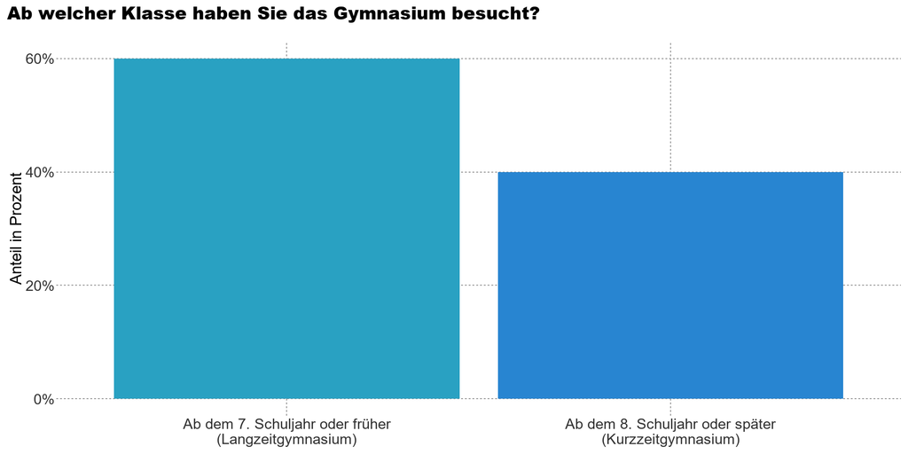

## Metadaten bearbeiten

**Funktionsübersicht**

Metadaten sollen nicht nur genutzt sondern auch gepflegt werden. Das R-Package `metaSABSEB` bietet auch Funktionen zum Unterhalt des Metadatensatzes an.

- `metaSABSEB::change_meta()`: Ändert Metadateneinträge von bereits erfassten Variablen
- `metaSABSEB::add_meta()`: Fügt dem Metadatensatz eine neue Variable inkl. erforderlicher Metadatenfelder hinzu.
- `metaSABSEB::delete_meta()`: Löscht alle Metadateneinträge einer Variable.

## Metadaten bearbeiten

**Prozess**

1. Package lokal klonen
2. Einen neuen Branch erstellen und in diesem Branch arbeiten
3. Änderungen mit `change_meta()`, `add_meta()` und `delete_meta` vornehmen.
4. Commit
5. Push
6. Pull-Request für Überführung in den Main-Branch

**Wie genau das funktioniert, können wir gemeinsam an einem Beispiel durchspielen.**